# 9_BasicPlotsAsNotebook

Niall McGuinness

October, 2022

# 1 Visualising Data with R Studio

The first block of R code in this r Notebook will download any necessary packages, compile where necessary and load them for use in this file.

## 1.1 Load Packages

We include tidyr because it allows us to support tables that are paged (e.g. line 66 when we output the chickwts data).

Change include to TRUE and see what happens when you Knit the output HTML document.

## 1.2 Show Available Data Sets

We should probably comment out this code as it keeps opening and switching to the Viewer window!

## 1.3 Examine Data

Change echo to TRUE and see what happens when you Knit the output HTML document.

| weight | feed |
| --- | --- |
| 179 | horsebean |
| 160 | horsebean |
| 136 | horsebean |
| 227 | horsebean |
| 217 | horsebean |
| 168 | horsebean |
| 108 | horsebean |
| 124 | horsebean |
| 143 | horsebean |
| 140 | horsebean |

[output cut: 61 more lines]

```
##  [1] horsebean horsebean horsebean horsebean horsebean horsebean horsebean
##  [8] horsebean horsebean horsebean linseed   linseed   linseed   linseed
## [15] linseed   linseed   linseed   linseed   linseed   linseed   linseed
## [22] linseed   soybean   soybean   soybean   soybean   soybean   soybean
## [29] soybean   soybean   soybean   soybean   soybean   soybean   soybean
## [36] soybean   sunflower sunflower sunflower sunflower sunflower sunflower
## [43] sunflower sunflower sunflower sunflower sunflower sunflower meatmeal
## [50] meatmeal  meatmeal  meatmeal  meatmeal  meatmeal  meatmeal  meatmeal
## [57] meatmeal  meatmeal  meatmeal  casein    casein    casein    casein
## [64] casein    casein    casein    casein    casein    casein    casein
## [71] casein
## Levels: casein horsebean linseed meatmeal soybean sunflower
```

```
## [1] "weight" "feed"
```

```
## 'data.frame':    71 obs. of  2 variables:
##  $ weight: num  179 160 136 227 217 168 108 124 143 140 ...
##  $ feed  : Factor w/ 6 levels "casein","horsebean",..: 2 2 2 2 2 2 2 2 2 2 ...
```

|  | weight | feed |
| --- | --- | --- |
| 1 | 179 | horsebean |
| 2 | 160 | horsebean |
| 3 | 136 | horsebean |
| 4 | 227 | horsebean |
| 5 | 217 | horsebean |
| 6 | 168 | horsebean |
| 7 | 108 | horsebean |
| 8 | 124 | horsebean |
| 9 | 143 | horsebean |
| 10 | 140 | horsebean |

|  | weight | feed |
| --- | --- | --- |
| 60 | 368 | casein |
| 61 | 390 | casein |
| 62 | 379 | casein |
| 63 | 260 | casein |
| 64 | 404 | casein |
| 65 | 318 | casein |
| 66 | 352 | casein |
| 67 | 359 | casein |
| 68 | 216 | casein |
| 69 | 222 | casein |

[output cut: 2 more lines]

```
##      weight             feed
##  Min.   :108.0   casein   :12
##  1st Qu.:204.5   horsebean:10
##  Median :258.0   linseed  :12
##  Mean   :261.3   meatmeal :11
##  3rd Qu.:323.5   soybean  :14
##  Max.   :423.0   sunflower:12
```

## 1.4 Example - Stripchart

A Stripchart with title (main) and plot character (pch) set. Try typing ?pch in the console and hitting Enter to see help on what difference values for pch will look like.

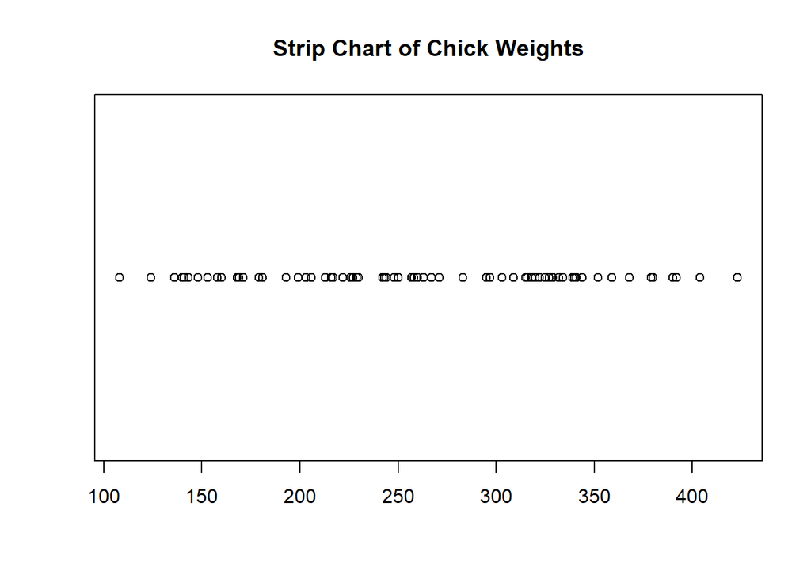

```r
# title and plotting character set
stripchart(chickwts$weight,
           main = "Strip Chart of Chick Weights",
           pch = 21)
```

A Histogram with title (main) and x/y labels (xlab, ylab) and color set. Try setting color using rgb() (e.g., col = rgb(1,0,0) or col = “#FF0000”).

For more information on HTML Hex Codes click [here](https://htmlcolorcodes.com/). To find color palettes that are compatible use one of the color palette pickers located [here](https://htmlcolorcodes.com/resources/best-color-palette-generators/)

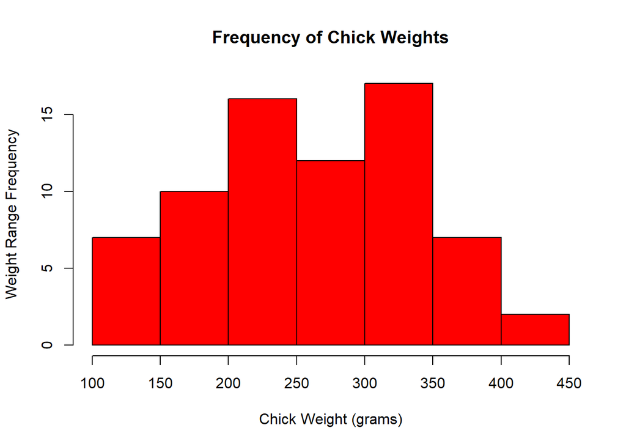

```r
# title and xy labels and color
hist(chickwts$weight, main = "Frequency of Chick Weights",
     xlab = "Chick Weight (grams)",
     ylab = "Weight Range Frequency",
     col = "red")
```

## 1.6 Example - Boxplot - 1

A simple Boxplot with title and y-label.

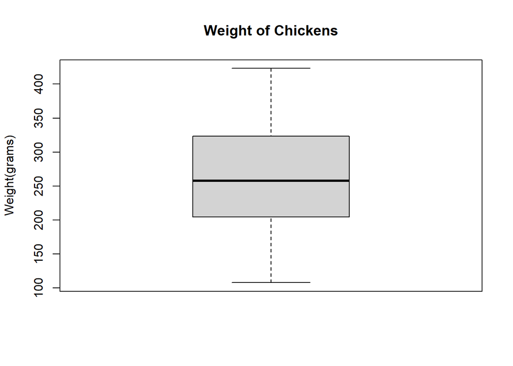

```r
# simple box plot
boxplot(chickwts$weight,
        main = "Weight of Chickens",
        ylab = "Weight(grams)")
```

## 1.7 Example - Boxplot - 2

A Boxplot comparing across a number of categories using ~.

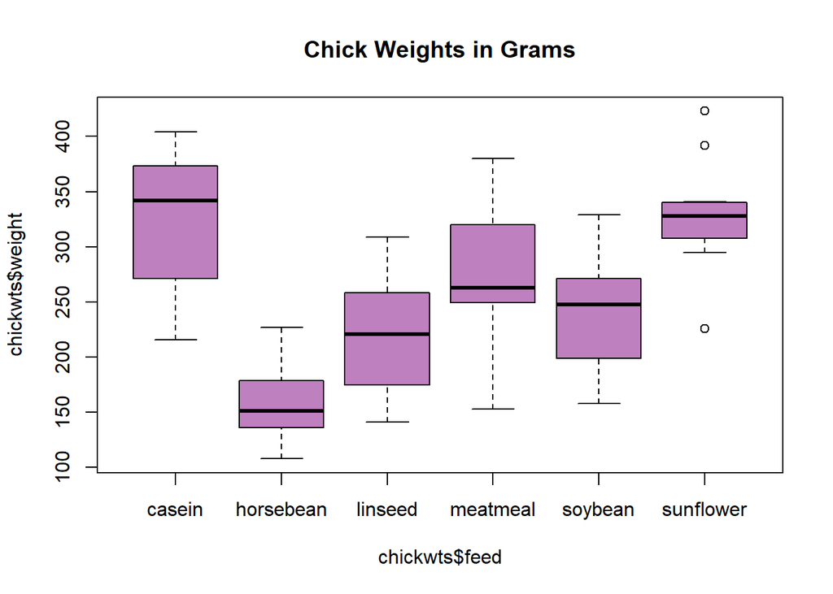

```r
# box-plot (multiple categories using ~)
boxplot(chickwts$weight~chickwts$feed,
        main = "Chick Weights in Grams",
        col = rgb(0.75, 0.5, 0.75))
```

A Piechart using data defined in two vectors. Title, labels, edges, border, and colors for each pie segment have been set.

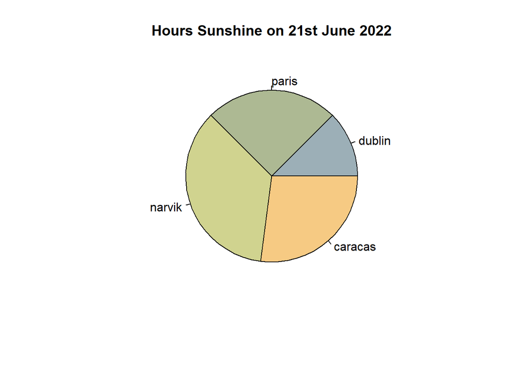

```r
sunshinePerDay <- c(6, 12, 17, 13)
cities <- c("dublin", "paris", "narvik", "caracas")

# uncomment the parameters (i.e. edges, main, border) to see what each parameter does
pie(x = sunshinePerDay,
    labels = cities,
    edges = 64,
    main = "Hours Sunshine on 21st June 2022",
    border = TRUE,
    col = c("#9CAFB7","#ADB993","#D0D38F","#F6CA83"))
```